# Homework 2

Peter Jenkins

February 11, 2021

1. Calculate the residuals. Use the summary() function applied to your numeric vector of residuals to verify that this matches the Residuals: quantiles reported from the summary of your fitted model. Plot a histogram of your residuals. Do they appear reasonably Gaussian? (we will go into detail on formal model checking later in the semester)

```r
#install.packages("ggplot2")
library("ggplot2")

beach <- read.csv("beach.csv")
head(beach)
```

```
##   BeachID Year OpenBeach
## 1       A 1992     437.8
## 2       A 1993     423.6
## 3       A 1994     333.1
## 4       A 1995     287.4
## 5       A 1996     295.6
## 6       A 1998     201.8
```

```r
fit <-lm(formula = OpenBeach ~ Year * BeachID , data = beach)
summary(fit)
```

```
##
## Call:
## lm(formula = OpenBeach ~ Year * BeachID, data = beach)
##
## Residuals:
##     Min      1Q  Median      3Q     Max
## -80.203 -21.460  -1.434  13.385  89.529
##
## Coefficients:
##                 Estimate Std. Error t value Pr(>|t|)
## (Intercept)    36945.725   2547.493  14.503  < 2e-16 ***
## Year             -18.365      1.272 -14.443  < 2e-16 ***
## BeachIDB      -34211.979   3602.404  -9.497 2.87e-13 ***
## BeachIDC      -28776.115   3602.404  -7.988 8.09e-11 ***
## Year:BeachIDB     17.043      1.798   9.478 3.07e-13 ***
## Year:BeachIDC     14.371      1.798   7.992 7.96e-11 ***
## ---
## Signif. codes:  0 '***' 0.001 '**' 0.01 '*' 0.05 '.' 0.1 ' ' 1
##
## Residual standard error: 39.46 on 56 degrees of freedom
## Multiple R-squared:  0.8298, Adjusted R-squared:  0.8146
## F-statistic: 54.62 on 5 and 56 DF,  p-value: < 2.2e-16
```

```r
# first calculating dummy variables for levels b and c
beach$b <- ifelse(beach$BeachID == 'B', 1, 0)
beach$c <- ifelse(beach$BeachID == 'C', 1, 0)

# storing coefficient for quick retrieval
b <- coef(fit)
b
```

```
##   (Intercept)          Year      BeachIDB      BeachIDC Year:BeachIDB
##   36945.72537     -18.36491  -34211.97897  -28776.11491      17.04277
## Year:BeachIDC
##      14.37132
```

```r
# predicting new values for y (manually calculating y)
prd <- b[1] +               # intercept value
  b[2] * beach$Year  +           #year
 b[3] * beach$b     +        # b dummy var
 b[4] * beach$c      +        # c dummy variable
 b[5] * beach$Year * beach$b   +           # interaction year and b
 b[6] * beach$Year * beach$c    # interaction betweenyear and c

prd
```

```
##  [1] 362.815029 344.450114 326.085199 307.720285 289.355370 252.625540
##  [7] 234.260625 197.530796 179.165881 160.800966 124.071136 105.706221
## [13]  87.341307  68.976392  50.611477  32.246562  13.881647  -4.483268
## [19] -22.848182 -41.213097 100.034035  98.711891  97.389746  96.067601
## [25]  94.745456  92.101167  90.779022  88.134733  86.812588  85.490443
## [31]  84.168298  82.846153  81.524009  80.201864  78.879719  77.557574
## [37]  76.235430  74.913285  73.591140  72.268995  70.946851 214.374389
## [43] 210.380797 206.387205 202.393612 198.400020 190.412835 186.419243
## [49] 178.432058 174.438465 170.444873 166.451281 162.457688 158.464096
## [55] 154.470503 150.476911 146.483319 142.489726 138.496134 134.502541
## [61] 130.508949 126.515356
```

```r
# calculating residuals ( real - predited values)
res <- beach$OpenBeach - prd
summary(res)
```

```
##    Min. 1st Qu.  Median    Mean 3rd Qu.    Max.
## -80.203 -21.460  -1.434   0.000  13.385  89.529
```

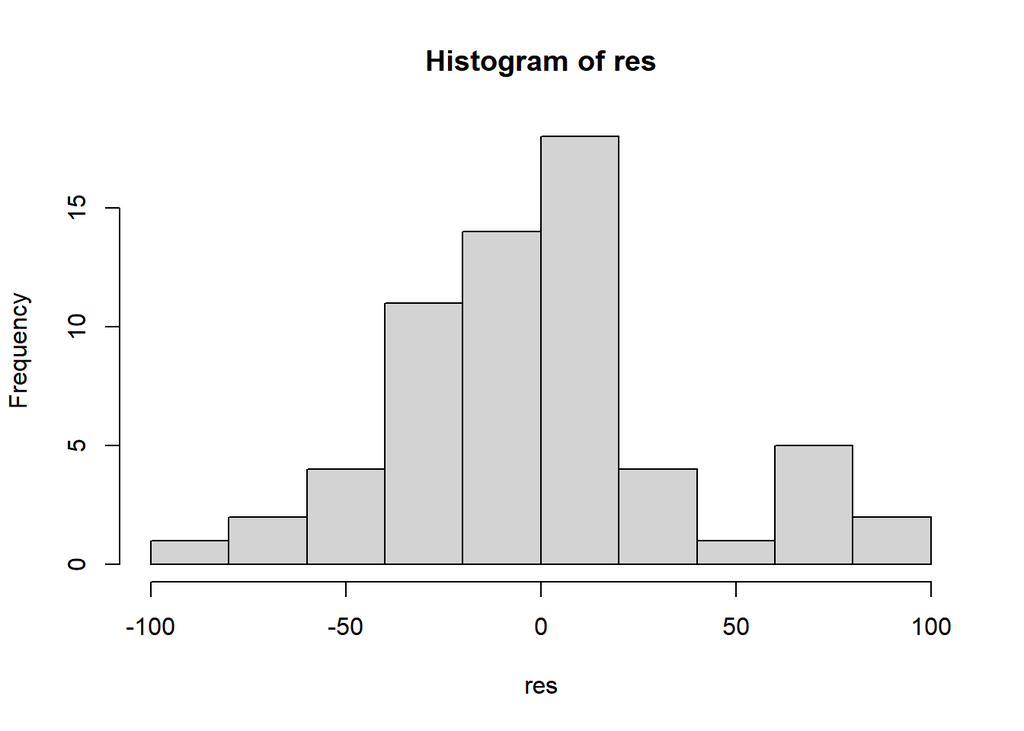

```r
hist(res)
```

Yes based off of the Histogram above the residuals are close enough a normal distribution.

2. Calculate test statistics for your regression coefficients. Verify by comparing to test statistics reported from model output.

```r
######
## for intercept
#####

b_0 <- coef(fit)[1]
#b_0
# estimate standard error
s_b <- summary(fit)[["coefficients"]]['(Intercept)','Std. Error']
#s_b
# null hypothesis
B_0 <- 0

# test stat   coefficient - null hypothesis (in this case 0) / standard error
t1 <- (b_0 - B_0)/ s_b
t1
```

```
## (Intercept)
##    14.50278
```

```r
##########
### returns fitted model slope coef
##########
b_1 <- coef(fit)[2]
#b_1
# estimate standard error
s_b <- summary(fit)[["coefficients"]]['Year','Std. Error']
#s_b
# null hypothesis
B_1 <- 0

# test stat
t2 <- (b_1 - B_1)/ s_b
t2
```

```
##      Year
## -14.44263
```

```r
#####

######
## for Beach B
#####

b_3 <- coef(fit)[3]
#b_0
# estimate standard error
s_b <- summary(fit)[["coefficients"]]['BeachIDB','Std. Error']
#s_b
# null hypothesis
B_0 <- 0

# test stat   coefficient - null hypothesis (in this case 0) / standard error
t3 <- (b_3 - B_0)/ s_b
t3
```

```
##  BeachIDB
## -9.496986
```

```r
#####


######
## for Beach C
#####

b_4 <- coef(fit)[4]
#b_0
# estimate standard error
s_b <- summary(fit)[["coefficients"]]['BeachIDC','Std. Error']
#s_b
# null hypothesis
B_0 <- 0

# test stat   coefficient - null hypothesis (in this case 0) / standard error
t4 <- (b_4 - B_0)/ s_b
t4
```

```
##  BeachIDC
## -7.988032
```

```r
#####

######
## for Beach B Interaction with Year
#####

b_5 <- coef(fit)[5]
#b_0
# estimate standard error
s_b <- summary(fit)[["coefficients"]]['Year:BeachIDB','Std. Error']
#s_b
# null hypothesis
B_0 <- 0

# test stat   coefficient - null hypothesis (in this case 0) / standard error
t5 <- (b_5 - B_0)/ s_b
t5
```

```
## Year:BeachIDB
##      9.478096
```

```r
#####

######
## for Beach C Interaction with Year
#####

b_6 <- coef(fit)[6]
#b_0
# estimate standard error
s_b <- summary(fit)[["coefficients"]]['Year:BeachIDC','Std. Error']
#s_b
# null hypothesis
B_0 <- 0

# test stat   coefficient - null hypothesis (in this case 0) / standard error
t6 <- (b_6 - B_0)/ s_b
t6
```

```
## Year:BeachIDC
##      7.992408
```

```r
#####

########
```

3. Calculate p-values for your regression coefficients. Verify by comparing to p-values reported from model output. What are the associated null hypotheses? Do you reject or fail to reject these null hypotheses? Note: in the lecture slides I reported test statistics are t-distributed with n − 2 degrees of freedom. More generally, these test statistics are t-distributed with n − k degrees of freedom, where k is the number of regression coefficients in your linear model. (5 points)

```r
# under assumptions of null hypothesis the test stat is t distributed with n-2 degree freedom
rdf <- nrow(beach) - 6  # 62 - 6 number of observations minus total number of coefficient

 tval <- rbind(t1, t2, t3, t4, t5,t6)

#####
#  P value
#####
# prob of observation larger or smaller than test statistic ************ homework
# two tailed
for( i in tval) {

 pval <- 2 * pt(abs(i), df = rdf, lower.tail = FALSE)
 print(pval)}  # abs allow for always positive. -1 in first part puts you in lower and left hand side...  1- abs gives upper side and to the right hand side
```

```
## [1] 1.296196e-20
## [1] 1.558806e-20
## [1] 2.868075e-13
## [1] 8.090204e-11
## [1] 3.07437e-13
## [1] 7.957165e-11
```

```r
#####
summary(fit)
```

```
##
## Call:
## lm(formula = OpenBeach ~ Year * BeachID, data = beach)
##
## Residuals:
##     Min      1Q  Median      3Q     Max
## -80.203 -21.460  -1.434  13.385  89.529
##
## Coefficients:
##                 Estimate Std. Error t value Pr(>|t|)
## (Intercept)    36945.725   2547.493  14.503  < 2e-16 ***
## Year             -18.365      1.272 -14.443  < 2e-16 ***
## BeachIDB      -34211.979   3602.404  -9.497 2.87e-13 ***
## BeachIDC      -28776.115   3602.404  -7.988 8.09e-11 ***
## Year:BeachIDB     17.043      1.798   9.478 3.07e-13 ***
## Year:BeachIDC     14.371      1.798   7.992 7.96e-11 ***
## ---
## Signif. codes:  0 '***' 0.001 '**' 0.01 '*' 0.05 '.' 0.1 ' ' 1
##
## Residual standard error: 39.46 on 56 degrees of freedom
## Multiple R-squared:  0.8298, Adjusted R-squared:  0.8146
## F-statistic: 54.62 on 5 and 56 DF,  p-value: < 2.2e-16
```

The null hypothesis are all that there is no impact on the area of open beach. H0 = 0 Ha does not = 0 . We rejected the null hypothesis because of our small pvalues.

4. Select a single regression coefficient (your choice) and devise a null hypothesis that is different from the default in lm(). Report the test statistics, your p-value, and whether you reject or fail to reject your null hypothesis. (5 points)

```r
##########
### returns fitted model slope coef or impact of year on beach
# null hypothesis is that we lost an average of 10 ha of beach based on previous study of sea level rise
##########
b_1 <- coef(fit)[2]
#b_1
# estimate standard error
s_b <- summary(fit)[["coefficients"]]['Year','Std. Error']
#s_b
# null hypothesis
B_1 <- -10

# test stat
t2 <- (b_1 - B_1)/ s_b
t2
```

```
##      Year
## -6.578378
```

```r
#####

rdf <- nrow(beach) - 6  # 62 - 6 number of observations minus total number of coefficient

 tval <- rbind(t1, t2, t3, t4, t5,t6)

#####
#  P value
#####
# prob of observation larger or smaller than test statistic ************ homework
# two tailed
 pval <- 2 * pt(abs(t2), df = rdf, lower.tail = FALSE)
 pval
```

```
##         Year
## 1.716851e-08
```

```r
   # abs allow for always positive. -1 in first part puts you in lower and left hand side...  1- abs gives upper side and to the right hand side
#####
```

Our null hypothesis was that B_1= -10 .

Test statistic = -6.58 Pval = 1.72 e-08

We reject our null hypothesis. Which means we are losing more beach than 10 ha a year.

5. Interpret output of your fitted model. Tell me how beach area does (or does not change) through time at each of the 3 beaches.

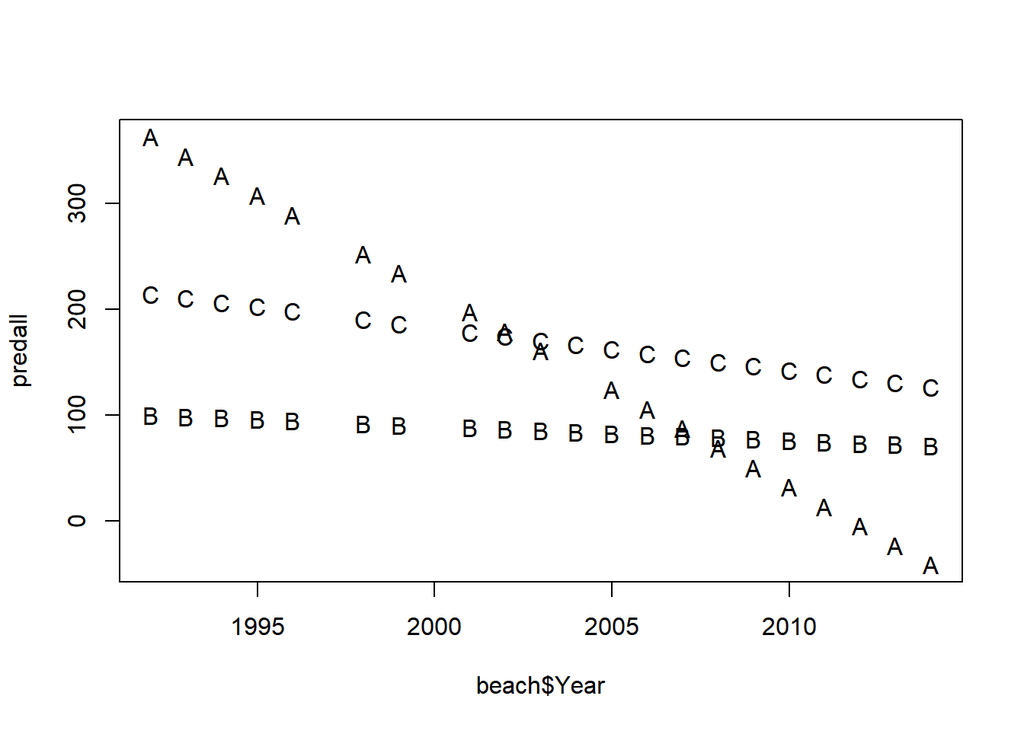

```r
predall <- predict(fit, beach)
names(predall) <- beach$BeachID

plot(beach$Year,predall, pch= beach$BeachID)
```

```r
beacha <- subset(beach, beach$BeachID == "A")
beachb <- subset(beach, beach$BeachID == "B")
beachc <- subset(beach, beach$BeachID== "C")



fit <-lm(formula = OpenBeach ~ Year  , data = beacha)
summary(fit)
```

```
##
## Call:
## lm(formula = OpenBeach ~ Year, data = beacha)
##
## Residuals:
##     Min      1Q  Median      3Q     Max
## -71.301 -22.869  -8.066  24.685  79.150
##
## Coefficients:
##              Estimate Std. Error t value Pr(>|t|)
## (Intercept) 36945.725   2901.033   12.73 1.93e-10 ***
## Year          -18.365      1.448  -12.68 2.06e-10 ***
## ---
## Signif. codes:  0 '***' 0.001 '**' 0.01 '*' 0.05 '.' 0.1 ' ' 1
##
## Residual standard error: 44.93 on 18 degrees of freedom
## Multiple R-squared:  0.8994, Adjusted R-squared:  0.8938
## F-statistic: 160.8 on 1 and 18 DF,  p-value: 2.061e-10
```

```r
fit <-lm(formula = OpenBeach ~ Year  , data = beachb)
summary(fit)
```

```
##
## Call:
## lm(formula = OpenBeach ~ Year, data = beachb)
##
## Residuals:
##     Min      1Q  Median      3Q     Max
## -38.768  -8.234   3.787  12.342  23.188
##
## Coefficients:
##              Estimate Std. Error t value Pr(>|t|)
## (Intercept) 2733.7464  1129.6465   2.420   0.0257 *
## Year          -1.3221     0.5639  -2.345   0.0301 *
## ---
## Signif. codes:  0 '***' 0.001 '**' 0.01 '*' 0.05 '.' 0.1 ' ' 1
##
## Residual standard error: 17.5 on 19 degrees of freedom
## Multiple R-squared:  0.2244, Adjusted R-squared:  0.1836
## F-statistic: 5.498 on 1 and 19 DF,  p-value: 0.03005
```

```r
fit <-lm(formula = OpenBeach ~ Year  , data = beachc)
summary(fit)
```

```
##
## Call:
## lm(formula = OpenBeach ~ Year, data = beachc)
##
## Residuals:
##     Min      1Q  Median      3Q     Max
## -80.203 -33.594  -7.319  13.691  89.529
##
## Coefficients:
##             Estimate Std. Error t value Pr(>|t|)
## (Intercept) 8169.610   3142.418   2.600   0.0176 *
## Year          -3.994      1.569  -2.546   0.0197 *
## ---
## Signif. codes:  0 '***' 0.001 '**' 0.01 '*' 0.05 '.' 0.1 ' ' 1
##
## Residual standard error: 48.68 on 19 degrees of freedom
## Multiple R-squared:  0.2544, Adjusted R-squared:  0.2152
## F-statistic: 6.483 on 1 and 19 DF,  p-value: 0.01972
```

Beach A decreases by 18.365 ha each year.

Beach B decreases by -1.3221 ha each year.

Beach C decreases by -3.994 ha each year.

Please hand in both the html document and the .Rmd document to GitHub.